# Rafa video on genes as genomic ranges

Michael Hunt

April 10, 2016

## Rafa video on genes as granges

### Mapping genes to binding sites

```r
library(GenomicFeatures)
library(GenomicRanges)
library(IRanges)
library(ERBS)
```

Load reported binding sites for two diferent cell lines. These are two GRanges

```r
data(HepG2) # cell line of liver origin
data(GM12878) # immortalized B cell
```

```r
#browseVignettes("GenomicRanges")
```

Now we want to find only the regions reported to be binding sites that are common to both GRanges

```r
res<-findOverlaps(HepG2,GM12878)
res
```

```
## Hits object with 75 hits and 0 metadata columns:
##        queryHits subjectHits
##        <integer>   <integer>
##    [1]         1          12
##    [2]         2          78
##    [3]         4         777
##    [4]         5           8
##    [5]         8          13
##    ...       ...         ...
##   [71]       285         621
##   [72]       287         174
##   [73]       291        1855
##   [74]       294         512
##   [75]       300         144
##   -------
##   queryLength: 303
##   subjectLength: 1873
```

```r
class(res) # a Hit, not a data frame
```

```
## [1] "Hits"
## attr(,"package")
## [1] "S4Vectors"
```

```r
index<-queryHits(res)
erbs<-HepG2[index,]
erbs<-granges(erbs) # extracts just the regions info.
erbs
```

```
## GRanges object with 75 ranges and 0 metadata columns:
##        seqnames                 ranges strand
##           <Rle>              <IRanges>  <Rle>
##    [1]     chr2   [20335378, 20335787]      *
##    [2]    chr20   [  328285,   329145]      *
##    [3]    chr19   [ 1244419,  1245304]      *
##    [4]    chr11   [64071828, 64073069]      *
##    [5]     chr2   [16938364, 16938840]      *
##    ...      ...                    ...    ...
##   [71]    chr12 [118558730, 118559158]      *
##   [72]     chr1 [ 35331750,  35332300]      *
##   [73]     chr1 [ 26146200,  26147004]      *
##   [74]     chr6 [ 44224657,  44225693]      *
##   [75]     chr1 [110198573, 110199126]      *
##   -------
##   seqinfo: 93 sequences (1 circular) from hg19 genome
```

So now we have picked out from HepG2 only those ranges that match a range in G12878 (match or overlap??)

Now load up some gene information.

```r
library(Homo.sapiens)
```

extract genes from this

```r
ghs=genes(Homo.sapiens)
ghs
```

```
## GRanges object with 23056 ranges and 1 metadata column:
##         seqnames                 ranges strand   |       GENEID
##            <Rle>              <IRanges>  <Rle>   | <FactorList>
##       1    chr19 [ 58858172,  58874214]      -   |            1
##      10     chr8 [ 18248755,  18258723]      +   |           10
##     100    chr20 [ 43248163,  43280376]      -   |          100
##    1000    chr18 [ 25530930,  25757445]      -   |         1000
##   10000     chr1 [243651535, 244006886]      -   |        10000
##     ...      ...                    ...    ... ...          ...
##    9991     chr9 [114979995, 115095944]      -   |         9991
##    9992    chr21 [ 35736323,  35743440]      +   |         9992
##    9993    chr22 [ 19023795,  19109967]      -   |         9993
##    9994     chr6 [ 90539619,  90584155]      +   |         9994
##    9997    chr22 [ 50961997,  50964905]      -   |         9997
##   -------
##   seqinfo: 93 sequences (1 circular) from hg19 genome
```

Get series of ids, locations, start and end, and strand + or -. Direction of transcription is different for each strand. For + strand, transcription start is at left, lowest number For - strand, transcription start is at right, highest number

### use of `precede`

erbs - these are locations where a protein binds to the genome. And the idea here is that some of these proteins that we study are transcription factors, that they bind *in front* of where the gene starts, and that helps the gene expression occur. So we’re really interested in– we’re many times more interested in sites that are *ahead* of the transcription start site, but that means different things depending on if you’re plus or minus.

So one of the advantages of using genomic ranges is that it has all these tools that already recognize that.

```r
#?precede
```

```r
index=precede(erbs,ghs,ignore.strand=FALSE)
index
```

```
##  [1] 16845 16173 21772 13617 18834 15172  4543 22522 21943 22493   846
## [12] 15836  3903 21053 18112 17682 19650 22112 21746 22839 14568  9043
## [23] 20477 12830  9841  5379 21643 14441 12911   553  7980  6028 22699
## [34]  4480 11293 20120 11859 17016 14199  6719 22946  2693  6923 20570
## [45]  6680 15953 17932 20311  8049 11969  3738  2914  1642  4173  6443
## [56]  4446 15062 11268 16695  3496  8458   568 22406  3201 14099 13558
## [67]  8545  7569 13718 16702 13095 17686 19348 12849  9552
```

`index` is a vector of indices that tells us, for each entry in erbs, what is the entry in ghs that is closest to it but precedes it.

```r
ghs[index[1:3]] # Rafa got a different first gene.
```

```
## GRanges object with 3 ranges and 1 metadata column:
##         seqnames               ranges strand |       GENEID
##            <Rle>            <IRanges>  <Rle> | <FactorList>
##    6382     chr2 [20400558, 20425194]      - |         6382
##   57761    chr20 [  361308,   378203]      + |        57761
##   90007    chr19 [ 1248552,  1259142]      + |        90007
##   -------
##   seqinfo: 93 sequences (1 circular) from hg19 genome
```

```r
erbs[1:3]
```

```
## GRanges object with 3 ranges and 0 metadata columns:
##       seqnames               ranges strand
##          <Rle>            <IRanges>  <Rle>
##   [1]     chr2 [20335378, 20335787]      *
##   [2]    chr20 [  328285,   329145]      *
##   [3]    chr19 [ 1244419,  1245304]      *
##   -------
##   seqinfo: 93 sequences (1 circular) from hg19 genome
```

Problem here? precede should have recognised that chr2 was on - strand and returned a larger start site number in ghs

### Find distances

```r
distance(erbs,ghs[index])
```

```
##  [1]   64770   32162    3247   11095  753145   26842   23629   30227
##  [9]   26140    2758 1019286   30950   10524   16769   27278   50750
## [17]  172769   12327   14252    2498   11043    7967  141361   22090
## [25] 1869429  212585  343959   16766   14601   43645   12855    6658
## [33]   15251  676306    3392  743687    5773   67629   47697   23757
## [41]   48629   29955    9688    5064    4930      59     880   14276
## [49]  407428  103611    3002    1826     676  441666    4848    7113
## [57]   60815    3682   25695   54785  121304  125168   10252   24972
## [65]   14696   39814     660     476   17261   24300   14711  108999
## [73]   13492     209   31291
```

Now define distance differently. For each binding site, find transcription start site that is closest, taking strand into accout. UIse `resize`

```r
tssgr<-resize(ghs,1)
d<-distanceToNearest(erbs,tssgr)
```

d is a Hits object, so cannot subset like a matrix.

```r
queryHits(d)
```

```
##  [1]  1  2  3  4  5  6  7  8  9 10 11 12 13 14 15 16 17 18 19 20 21 22 23
## [24] 24 25 26 27 28 29 30 31 32 33 34 35 36 37 38 39 40 41 42 43 44 45 46
## [47] 47 48 49 50 51 52 53 54 55 56 57 58 59 60 61 62 63 64 65 66 67 68 69
## [70] 70 71 72 73 74 75
```

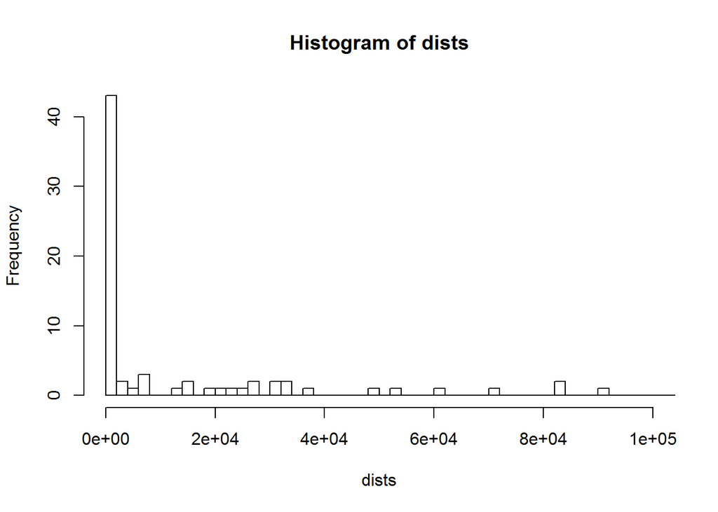

```r
dists<-values(d)$distance
hist(dists,nc=1000,xlim=c(0,100000))
```

We see that many of the bindng sites are very close to the transcription start sites -> biology insights

### Closerlook at the genes close to the transcription start sites

let’s find those that are very close - less than 1000 sites away from binding sites

```r
index=subjectHits(d)[dists<1000]
index
```

```
##  [1] 19883  6316 18488 14325  9348 19622 19678 16536  4171 13017 21240
## [12] 22438 10812 20840 13796  8334  2185  2917 16265  6286 21787 14490
## [23] 17932 13607  3681  1642 21117  2204 14339 12775 13722 16883 19605
## [34] 15633  7235  6077 14605  3119 15380 10503  9555
```

### Annotating genes

Use `select` function to query the Homo.sapiens data base.

This will need a key. Get the key from here:

```r
tssgr[index,]
```

```
## GRanges object with 41 ranges and 1 metadata column:
##          seqnames                 ranges strand   |       GENEID
##             <Rle>              <IRanges>  <Rle>   | <FactorList>
##    80023    chr20 [   327370,    327370]      +   |        80023
##     2101    chr11 [ 64073044,  64073044]      +   |         2101
##     7086     chr3 [ 53290130,  53290130]      -   |         7086
##     5478     chr7 [ 44836241,  44836241]      +   |         5478
##   286262     chr9 [140095163, 140095163]      -   |       286262
##      ...      ...                    ...    ... ...          ...
##    55090    chr17 [ 17380300,  17380300]      +   |        55090
##    11165     chr6 [ 34360457,  34360457]      -   |        11165
##    56181     chr1 [ 26146397,  26146397]      +   |        56181
##   347734     chr6 [ 44225283,  44225283]      -   |       347734
##     2948     chr1 [110198698, 110198698]      +   |         2948
##   -------
##   seqinfo: 93 sequences (1 circular) from hg19 genome
```

```r
keys<-as.character(values(tssgr[index])$GENEID)
```

We can use GENEID as key, since it is one of the avialable keytypes in Homo.sapiens:

```r
keytypes(Homo.sapiens)
```

```
##  [1] "ACCNUM"       "ALIAS"        "CDSID"        "CDSNAME"
##  [5] "DEFINITION"   "ENSEMBL"      "ENSEMBLPROT"  "ENSEMBLTRANS"
##  [9] "ENTREZID"     "ENZYME"       "EVIDENCE"     "EVIDENCEALL"
## [13] "EXONID"       "EXONNAME"     "GENEID"       "GENENAME"
## [17] "GO"           "GOALL"        "GOID"         "IPI"
## [21] "MAP"          "OMIM"         "ONTOLOGY"     "ONTOLOGYALL"
## [25] "PATH"         "PFAM"         "PMID"         "PROSITE"
## [29] "REFSEQ"       "SYMBOL"       "TERM"         "TXID"
## [33] "TXNAME"       "UCSCKG"       "UNIGENE"      "UNIPROT"
```

Now, what columns from Homo.sapiens? What information do we want?

What is available:

```r
columns(Homo.sapiens)
```

```
##  [1] "ACCNUM"       "ALIAS"        "CDSCHROM"     "CDSEND"
##  [5] "CDSID"        "CDSNAME"      "CDSSTART"     "CDSSTRAND"
##  [9] "DEFINITION"   "ENSEMBL"      "ENSEMBLPROT"  "ENSEMBLTRANS"
## [13] "ENTREZID"     "ENZYME"       "EVIDENCE"     "EVIDENCEALL"
## [17] "EXONCHROM"    "EXONEND"      "EXONID"       "EXONNAME"
## [21] "EXONRANK"     "EXONSTART"    "EXONSTRAND"   "GENEID"
## [25] "GENENAME"     "GO"           "GOALL"        "GOID"
## [29] "IPI"          "MAP"          "OMIM"         "ONTOLOGY"
## [33] "ONTOLOGYALL"  "PATH"         "PFAM"         "PMID"
## [37] "PROSITE"      "REFSEQ"       "SYMBOL"       "TERM"
## [41] "TXCHROM"      "TXEND"        "TXID"         "TXNAME"
## [45] "TXSTART"      "TXSTRAND"     "TXTYPE"       "UCSCKG"
## [49] "UNIGENE"      "UNIPROT"
```

```r
res=select(Homo.sapiens,keys=keys,keytype="GENEID",columns=c("SYMBOL","GENENAME"))
res[1:2,]
```

```
##   GENEID                        GENENAME SYMBOL
## 1  80023                     neurensin 2  NRSN2
## 2   2101 estrogen-related receptor alpha  ESRRA
```

second gene on the list is the gene related to the protein we are studying - > biology!